# My R Codes For Data Analysis

In this repository I am going to collect `R codes` for data analysis. Codes are from various resources and I try to give original link as much as possible.

[Serdar Balcı, MD, Pathologist](https://www.serdarbalci.com/)

2018-11-24

### 0.0.1 Compare Means

```r
t.test(scabies$age[scabies$gender=="male"],scabies$age[scabies$gender=="female"])
```

```r
test <- t.test(scabies$age[scabies$gender=="male"],scabies$age[scabies$gender=="female"])
psycho::analyze(test)
```

# 1 infer

Randomization Examples using nycflights13 flights data

https://cran.r-project.org/web/packages/infer/vignettes/flights_examples.html

```r
library(nycflights13)
library(dplyr)
library(ggplot2)
library(stringr)
library(infer)
set.seed(2017)
```

```r
fli_small <- flights %>%
  na.omit() %>%
  sample_n(size = 500) %>%
  mutate(season = case_when(
    month %in% c(10:12, 1:3) ~ "winter",
    month %in% c(4:9) ~ "summer"
  )) %>%
  mutate(day_hour = case_when(
    between(hour, 1, 12) ~ "morning",
    between(hour, 13, 24) ~ "not morning"
  )) %>%
  select(arr_delay, dep_delay, season,
         day_hour, origin, carrier)
fli_small
```

| arr_delay | dep_delay | season | day_hour | origin | carrier |
| --- | --- | --- | --- | --- | --- |
| 77 | 80 | summer | not morning | JFK | B6 |
| -11 | 0 | summer | not morning | JFK | B6 |
| 21 | -1 | winter | not morning | LGA | MQ |
| -20 | 0 | winter | not morning | LGA | MQ |
| -14 | -6 | summer | morning | JFK | B6 |
| 75 | 79 | summer | not morning | JFK | B6 |
| 7 | -6 | winter | not morning | EWR | UA |
| -33 | -9 | winter | morning | EWR | UA |
| -7 | -5 | winter | not morning | LGA | MQ |
| -8 | -7 | winter | not morning | LGA | DL |

[output cut: 490 more lines]

Hypothesis tests One numerical variable (mean)

```r
x_bar
```

[output not shown]

```
[1] 10.4
```

```r
null_distn <- fli_small %>%
  specify(response = dep_delay) %>%
  hypothesize(null = "point", mu = 10) %>%
  generate(reps = 1000, type = "bootstrap") %>%
  calculate(stat = "mean")
null_distn
```

| replicate | stat |
| --- | --- |
| 1 | 9.912 |
| 2 | 9.382 |
| 3 | 9.602 |
| 4 | 8.504 |
| 5 | 8.256 |
| 6 | 8.944 |
| 7 | 7.164 |
| 8 | 10.380 |
| 9 | 11.624 |
| 10 | 8.282 |

[output cut: 990 more lines]

[figure not shown]

```r
null_distn %>%
  summarize(p_value = mean(stat >= x_bar) * 2)
```

| p_value |
| --- |
| 0.794 |

One numerical variable (median)

```r
x_tilde <- fli_small %>%
  summarize(median(dep_delay)) %>%
  pull()
x_tilde
```

```
[1] -2
```

[output not shown]

[output cut: 990 more lines]

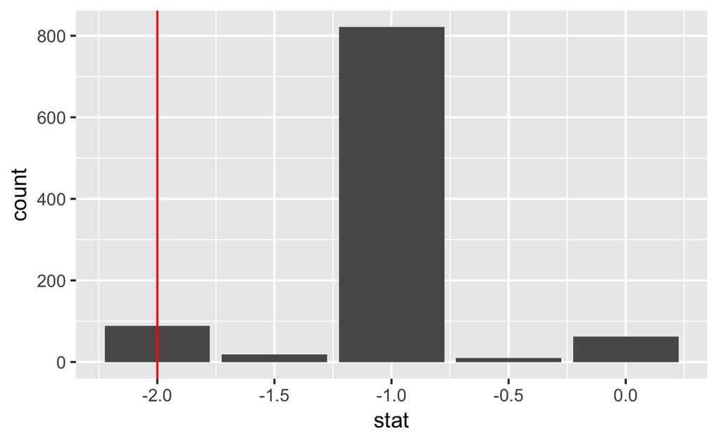

```r
ggplot(null_distn, aes(x = stat)) +
  geom_bar() +
  geom_vline(xintercept = x_tilde, color = "red")
```

```r
null_distn %>%
  summarize(p_value = mean(stat <= x_tilde) * 2)
```

| p_value |
| --- |
| 0.178 |

One categorical (one proportion)

```r
p_hat <- fli_small %>%
  summarize(mean(day_hour == "morning")) %>%
  pull()
p_hat
```

```
[1] 0.466
```

null_distn <- fli_small %>% specify(response = day_hour, success = “morning”) %>% hypothesize(null = “point”, p = .5) %>% generate(reps = 1000, type = “simulate”) %>% calculate(stat = “prop”) ggplot(null_distn, aes(x = stat)) + geom_bar() + geom_vline(xintercept = p_hat, color = “red”)

null_distn %>% summarize(p_value = mean(stat <= p_hat) * 2) p_value 0.132 Logical variables will be coerced to factors:

null_distn <- fli_small %>% mutate(day_hour_logical = (day_hour == “morning”)) %>% specify(response = day_hour_logical, success = “TRUE”) %>% hypothesize(null = “point”, p = .5) %>% generate(reps = 1000, type = “simulate”) %>% calculate(stat = “prop”) Two categorical (2 level) variables d_hat <- fli_small %>% group_by(season) %>% summarize(prop = mean(day_hour == “morning”)) %>% summarize(diff(prop)) %>% pull() null_distn <- fli_small %>% specify(day_hour ~ season, success = “morning”) %>% hypothesize(null = “independence”) %>% generate(reps = 1000, type = “permute”) %>% calculate(stat = “diff in props”, order = c(“winter”, “summer”)) ggplot(null_distn, aes(x = stat)) + geom_density() + geom_vline(xintercept = d_hat, color = “red”)

null_distn %>% summarize(p_value = mean(stat <= d_hat) * 2) %>% pull() ## [1] 0.758 One categorical (>2 level) - GoF Chisq_hat <- fli_small %>% specify(response = origin) %>% hypothesize(null = “point”, p = c(“EWR” = .33, “JFK” = .33, “LGA” = .34)) %>% calculate(stat = “Chisq”) null_distn <- fli_small %>% specify(response = origin) %>% hypothesize(null = “point”, p = c(“EWR” = .33, “JFK” = .33, “LGA” = .34)) %>% generate(reps = 1000, type = “simulate”) %>% calculate(stat = “Chisq”) ggplot(null_distn, aes(x = stat)) + geom_density() + geom_vline(xintercept = pull(Chisq_hat), color = “red”)

null_distn %>% summarize(p_value = mean(stat >= pull(Chisq_hat))) %>% pull() ## [1] 0.002 Two categorical (>2 level) variables Chisq_hat <- fli_small %>% chisq_stat(formula = day_hour ~ origin) null_distn <- fli_small %>% specify(day_hour ~ origin, success = “morning”) %>% hypothesize(null = “independence”) %>% generate(reps = 1000, type = “permute”) %>% calculate(stat = “Chisq”) ggplot(null_distn, aes(x = stat)) + geom_density() + geom_vline(xintercept = pull(Chisq_hat), color = “red”)

null_distn %>% summarize(p_value = mean(stat >= pull(Chisq_hat))) %>% pull() ## [1] 0.017 One numerical variable, one categorical (2 levels) (diff in means) d_hat <- fli_small %>% group_by(season) %>% summarize(mean_stat = mean(dep_delay)) %>% # Since summer - winter summarize(-diff(mean_stat)) %>% pull() null_distn <- fli_small %>% specify(dep_delay ~ season) %>% # alt: response = dep_delay, # explanatory = season hypothesize(null = “independence”) %>% generate(reps = 1000, type = “permute”) %>% calculate(stat = “diff in means”, order = c(“summer”, “winter”)) ggplot(null_distn, aes(x = stat)) + geom_density() + geom_vline(xintercept = d_hat, color = “red”)

null_distn %>% summarize(p_value = mean(stat <= d_hat) * 2) %>% pull() ## [1] 1.574 One numerical variable, one categorical (2 levels) (diff in medians) d_hat <- fli_small %>% group_by(season) %>% summarize(median_stat = median(dep_delay)) %>% # Since summer - winter summarize(-diff(median_stat)) %>% pull() null_distn <- fli_small %>% specify(dep_delay ~ season) %>% # alt: response = dep_delay, # explanatory = season hypothesize(null = “independence”) %>% generate(reps = 1000, type = “permute”) %>% calculate(stat = “diff in medians”, order = c(“summer”, “winter”)) ggplot(null_distn, aes(x = stat)) + geom_bar() + geom_vline(xintercept = d_hat, color = “red”)

null_distn %>% summarize(p_value = mean(stat >= d_hat) * 2) %>% pull() ## [1] 0.068 One numerical, one categorical (>2 levels) - ANOVA F_hat <- anova( aov(formula = arr_delay ~ origin, data = fli_small) )$`F value`[1] null_distn <- fli_small %>% specify(arr_delay ~ origin) %>% # alt: response = arr_delay, # explanatory = origin hypothesize(null = “independence”) %>% generate(reps = 1000, type = “permute”) %>% calculate(stat = “F”) ggplot(null_distn, aes(x = stat)) + geom_density() + geom_vline(xintercept = F_hat, color = “red”)

null_distn %>% summarize(p_value = mean(stat >= F_hat)) %>% pull() ## [1] 0.351 Two numerical vars - SLR slope_hat <- lm(arr_delay ~ dep_delay, data = fli_small) %>% broom::tidy() %>% filter(term == “dep_delay”) %>% pull(estimate) null_distn <- fli_small %>% specify(arr_delay ~ dep_delay) %>% hypothesize(null = “independence”) %>% generate(reps = 1000, type = “permute”) %>% calculate(stat = “slope”) ggplot(null_distn, aes(x = stat)) + geom_density() + geom_vline(xintercept = slope_hat, color = “red”)

Examples using mtcars data

https://cran.r-project.org/web/packages/infer/vignettes/mtcars_examples.html

Examples using mtcars data Chester Ismay and Andrew Bray 2018-01-05 Note: The type argument in generate() is automatically filled based on the entries for specify() and hypothesize(). It can be removed throughout the examples that follow. It is left in to reiterate the type of generation process being performed.

Data preparation library(infer) library(dplyr) mtcars <- mtcars %>% mutate(cyl = factor(cyl), vs = factor(vs), am = factor(am), gear = factor(gear), carb = factor(carb)) # For reproducibility  
set.seed(2018)  
One numerical variable (mean)

mtcars %>% specify(response = mpg) %>% # formula alt: mpg ~ NULL hypothesize(null = “point”, mu = 25) %>% generate(reps = 100, type = “bootstrap”) %>% calculate(stat = “mean”) ## # A tibble: 100 x 2 ## replicate stat ## ## 1 1 26.6 ## 2 2 25.1 ## 3 3 25.2 ## 4 4 24.7 ## 5 5 24.6 ## 6 6 25.8 ## 7 7 24.7 ## 8 8 25.6 ## 9 9 25.0 ## 10 10 25.1 ## # … with 90 more rows One numerical variable (median)

mtcars %>% specify(response = mpg) %>% # formula alt: mpg ~ NULL hypothesize(null = “point”, med = 26) %>% generate(reps = 100, type = “bootstrap”) %>% calculate(stat = “median”) ## # A tibble: 100 x 2 ## replicate stat ## ## 1 1 28.2 ## 2 2 27.2 ## 3 3 26.2 ## 4 4 26  
## 5 5 26.5 ## 6 6 24.5 ## 7 7 26  
## 8 8 28.2 ## 9 9 28.2 ## 10 10 23.2 ## # … with 90 more rows One categorical (2 level) variable

mtcars %>% specify(response = am, success = “1”) %>% # formula alt: am ~ NULL hypothesize(null = “point”, p = .25) %>% generate(reps = 100, type = “simulate”) %>% calculate(stat = “prop”) ## # A tibble: 100 x 2 ## replicate stat ## ## 1 1 0.375 ## 2 2 0.0625 ## 3 3 0.125 ## 4 4 0.25  
## 5 5 0.188 ## 6 6 0.406 ## 7 7 0.219 ## 8 8 0.375 ## 9 9 0.344 ## 10 10 0.188 ## # … with 90 more rows Two categorical (2 level) variables

mtcars %>% specify(am ~ vs, success = “1”) %>% # alt: response = am, explanatory = vs hypothesize(null = “independence”) %>% generate(reps = 100, type = “permute”) %>% calculate(stat = “diff in props”, order = c(“0”, “1”)) ## # A tibble: 100 x 2 ## replicate stat ## ## 1 1 -0.421 ## 2 2 -0.167 ## 3 3 -0.421 ## 4 4 -0.0397 ## 5 5 0.0873 ## 6 6 -0.0397 ## 7 7 -0.0397 ## 8 8 -0.0397 ## 9 9 0.0873 ## 10 10 -0.167 ## # … with 90 more rows One categorical (>2 level) - GoF

mtcars %>% specify(cyl ~ NULL) %>% # alt: response = cyl hypothesize(null = “point”, p = c(“4” = .5, “6” = .25, “8” = .25)) %>% generate(reps = 100, type = “simulate”) %>% calculate(stat = “Chisq”) ## # A tibble: 100 x 2 ## replicate stat ## ## 1 1 6.75 ## 2 2 1.69 ## 3 3 3.19 ## 4 4 1.69 ## 5 5 6  
## 6 6 2.69 ## 7 7 4.75 ## 8 8 0.75 ## 9 9 0.688 ## 10 10 3.69 ## # … with 90 more rows Two categorical (>2 level) variables

mtcars %>% specify(cyl ~ am) %>% # alt: response = cyl, explanatory = am hypothesize(null = “independence”) %>% generate(reps = 100, type = “permute”) %>% calculate(stat = “Chisq”) ## # A tibble: 100 x 2 ## replicate stat ## ## 1 1 1.34 ## 2 2 1.63 ## 3 3 1.63 ## 4 4 2.63 ## 5 5 3.90 ## 6 6 1.74 ## 7 7 0.126 ## 8 8 1.74 ## 9 9 1.34 ## 10 10 1.34 ## # … with 90 more rows One numerical variable one categorical (2 levels) (diff in means)

mtcars %>% specify(mpg ~ am) %>% # alt: response = mpg, explanatory = am hypothesize(null = “independence”) %>% generate(reps = 100, type = “permute”) %>% calculate(stat = “diff in means”, order = c(“0”, “1”)) ## # A tibble: 100 x 2 ## replicate stat ## ## 1 1 -1.10 ## 2 2 0.217 ## 3 3 -1.08 ## 4 4 -3.80 ## 5 5 3.08 ## 6 6 0.489 ## 7 7 2.34 ## 8 8 4.10 ## 9 9 -1.86 ## 10 10 -0.210 ## # … with 90 more rows One numerical variable one categorical (2 levels) (diff in medians)

mtcars %>% specify(mpg ~ am) %>% # alt: response = mpg, explanatory = am hypothesize(null = “independence”) %>% generate(reps = 100, type = “permute”) %>% calculate(stat = “diff in medians”, order = c(“0”, “1”)) ## # A tibble: 100 x 2 ## replicate stat ## ## 1 1 0.5 ## 2 2 -1.10 ## 3 3 5.20 ## 4 4 1.8 ## 5 5 0.5 ## 6 6 3.3 ## 7 7 -1.60 ## 8 8 -2.3 ## 9 9 2.90 ## 10 10 -0.5 ## # … with 90 more rows One numerical one categorical (>2 levels) - ANOVA

mtcars %>% specify(mpg ~ cyl) %>% # alt: response = mpg, explanatory = cyl hypothesize(null = “independence”) %>% generate(reps = 100, type = “permute”) %>% calculate(stat = “F”) ## # A tibble: 100 x 2 ## replicate stat ## ## 1 1 1.43 ## 2 2 1.65 ## 3 3 0.318 ## 4 4 0.393 ## 5 5 1.05 ## 6 6 0.826 ## 7 7 1.32 ## 8 8 0.833 ## 9 9 0.144 ## 10 10 0.365 ## # … with 90 more rows Two numerical vars - SLR

mtcars %>% specify(mpg ~ hp) %>% # alt: response = mpg, explanatory = cyl hypothesize(null = “independence”) %>% generate(reps = 100, type = “permute”) %>% calculate(stat = “slope”) ## # A tibble: 100 x 2 ## replicate stat ## ## 1 1 -0.0151 ## 2 2 0.00224 ## 3 3 -0.0120 ## 4 4 0.00292 ## 5 5 0.0203 ## 6 6 -0.00730 ## 7 7 -0.0246 ## 8 8 0.00555 ## 9 9 0.0109 ## 10 10 0.0176 ## # … with 90 more rows One numerical variable (standard deviation)

Not currently implemented

mtcars %>% specify(response = mpg) %>% # formula alt: mpg ~ NULL hypothesize(null = “point”, sigma = 5) %>% generate(reps = 100, type = “bootstrap”) %>% calculate(stat = “sd”) Confidence intervals One numerical (one mean)

mtcars %>% specify(response = mpg) %>% generate(reps = 100, type = “bootstrap”) %>% calculate(stat = “mean”) ## # A tibble: 100 x 2 ## replicate stat ## ## 1 1 19.6 ## 2 2 21.8 ## 3 3 18.7 ## 4 4 19.2 ## 5 5 21.6 ## 6 6 19.9 ## 7 7 20.7 ## 8 8 19.3 ## 9 9 21.2 ## 10 10 21.3 ## # … with 90 more rows One numerical (one median)

mtcars %>% specify(response = mpg) %>% generate(reps = 100, type = “bootstrap”) %>% calculate(stat = “median”) ## # A tibble: 100 x 2 ## replicate stat ## ## 1 1 19.2 ## 2 2 20.1 ## 3 3 21  
## 4 4 17.8 ## 5 5 20.1 ## 6 6 19.2 ## 7 7 18.4 ## 8 8 19.2 ## 9 9 19.2 ## 10 10 18.0 ## # … with 90 more rows One numerical (standard deviation)

mtcars %>% specify(response = mpg) %>% generate(reps = 100, type = “bootstrap”) %>% calculate(stat = “sd”) ## # A tibble: 100 x 2 ## replicate stat ## ## 1 1 5.28 ## 2 2 6.74 ## 3 3 5.29 ## 4 4 5.41 ## 5 5 5.56 ## 6 6 5.65 ## 7 7 6.17 ## 8 8 6.40 ## 9 9 6.31 ## 10 10 6.11 ## # … with 90 more rows One categorical (one proportion)

mtcars %>% specify(response = am, success = “1”) %>% generate(reps = 100, type = “bootstrap”) %>% calculate(stat = “prop”) ## # A tibble: 100 x 2 ## replicate stat ## ## 1 1 0.375 ## 2 2 0.406 ## 3 3 0.406 ## 4 4 0.312 ## 5 5 0.312 ## 6 6 0.469 ## 7 7 0.438 ## 8 8 0.281 ## 9 9 0.438 ## 10 10 0.5  
## # … with 90 more rows One numerical variable one categorical (2 levels) (diff in means)

mtcars %>% specify(mpg ~ am) %>% generate(reps = 100, type = “bootstrap”) %>% calculate(stat = “diff in means”, order = c(“0”, “1”)) ## # A tibble: 100 x 2 ## replicate stat ## ## 1 1 -9.38 ## 2 2 -5.11 ## 3 3 -4.88 ## 4 4 -5.39 ## 5 5 -9.19 ## 6 6 -7.20 ## 7 7 -5.34 ## 8 8 -3.20 ## 9 9 -5.95 ## 10 10 -11.0 ## # … with 90 more rows Two categorical variables (diff in proportions)

mtcars %>% specify(am ~ vs, success = “1”) %>% generate(reps = 100, type = “bootstrap”) %>% calculate(stat = “diff in props”, order = c(“0”, “1”)) ## # A tibble: 100 x 2 ## replicate stat ## ## 1 1 -0.352 ## 2 2 -0.15 ## 3 3 -0.294 ## 4 4 -0.254 ## 5 5 -0.438 ## 6 6 -0.126 ## 7 7 -0.188 ## 8 8 0.167 ## 9 9 -0.143 ## 10 10 -0.5  
## # … with 90 more rows Two numerical vars - SLR

mtcars %>% specify(mpg ~ hp) %>% generate(reps = 100, type = “bootstrap”) %>% calculate(stat = “slope”) ## # A tibble: 100 x 2 ## replicate stat ## ## 1 1 -0.0850 ## 2 2 -0.0512 ## 3 3 -0.0736 ## 4 4 -0.0569 ## 5 5 -0.0930 ## 6 6 -0.0659 ## 7 7 -0.0710 ## 8 8 -0.0767 ## 9 9 -0.0556 ## 10 10 -0.0627 ## # … with 90 more rows Two numerical vars - correlation

mtcars %>% specify(mpg ~ hp) %>% generate(reps = 100, type = “bootstrap”) %>% calculate(stat = “correlation”) ## # A tibble: 100 x 2 ## replicate stat ## ## 1 1 -0.821 ## 2 2 -0.812 ## 3 3 -0.802 ## 4 4 -0.723 ## 5 5 -0.885 ## 6 6 -0.777 ## 7 7 -0.752 ## 8 8 -0.758 ## 9 9 -0.826 ## 10 10 -0.779 ## # … with 90 more rows

Two sample t test example using nycflights13 flights data

https://cran.r-project.org/web/packages/infer/vignettes/two_sample_t.html

Two sample t test example using nycflights13 flights data Chester Ismay 2018-11-15 Note: The type argument in generate() is automatically filled based on the entries for specify() and hypothesize(). It can be removed throughout the examples that follow. It is left in to reiterate the type of generation process being performed.

Data preparation library(nycflights13) library(dplyr) library(stringr) library(infer) set.seed(2017) fli_small <- flights %>% sample_n(size = 500) %>% mutate(half_year = case_when( between(month, 1, 6) ~ “h1”, between(month, 7, 12) ~ “h2” )) %>% mutate(day_hour = case_when( between(hour, 1, 12) ~ “morning”, between(hour, 13, 24) ~ “not morning” )) %>% select(arr_delay, dep_delay, half_year, day_hour, origin, carrier) Two numeric - arr_delay, dep_delay Two categories half_year (“h1”, “h2”), day_hour (“morning”, “not morning”) Three categories - origin (“EWR”, “JFK”, “LGA”) Sixteen categories - carrier One numerical variable, one categorical (2 levels) Calculate observed statistic The recommended approach is to use specify() %>% calculate():

obs_t <- fli_small %>% specify(arr_delay ~ half_year) %>% calculate(stat = “t”, order = c(“h1”, “h2”)) ## Warning: Removed 15 rows containing missing values. The observed t statistic is stat 0.8685 .

Or using t_test in infer

obs_t <- fli_small %>% t_test(formula = arr_delay ~ half_year, alternative = “two_sided”, order = c(“h1”, “h2”)) %>% dplyr::pull(statistic) The observed t statistic is 0.8685.

Or using another shortcut function in infer:

obs_t <- fli_small %>% t_stat(formula = arr_delay ~ half_year, order = c(“h1”, “h2”)) The observed t statistic is statistic 0.8685 .

Randomization approach to t-statistic t_null_perm <- fli_small %>% # alt: response = arr_delay, explanatory = half_year specify(arr_delay ~ half_year) %>% hypothesize(null = “independence”) %>% generate(reps = 1000, type = “permute”) %>% calculate(stat = “t”, order = c(“h1”, “h2”)) ## Warning: Removed 15 rows containing missing values. visualize(t_null_perm) + shade_p_value(obs_stat = obs_t, direction = “two_sided”)

Calculate the randomization-based p-value t_null_perm %>% get_p_value(obs_stat = obs_t, direction = “two_sided”) p_value 0.408 Theoretical distribution t_null_theor <- fli_small %>% # alt: response = arr_delay, explanatory = half_year specify(arr_delay ~ half_year) %>% hypothesize(null = “independence”) %>% # generate() ## Not used for theoretical calculate(stat = “t”, order = c(“h1”, “h2”)) ## Warning: Removed 15 rows containing missing values. visualize(t_null_theor, method = “theoretical”) + shade_p_value(obs_stat = obs_t, direction = “two_sided”) ## Warning: Check to make sure the conditions have been met for the ## theoretical method. {infer} currently does not check these for you.

Overlay appropriate t distribution on top of permuted t-statistics visualize(t_null_perm, method = “both”) + shade_p_value(obs_stat = obs_t, direction = “two_sided”) ## Warning: Check to make sure the conditions have been met for the ## theoretical method. {infer} currently does not check these for you.

Compute theoretical p-value fli_small %>% t_test(formula = arr_delay ~ half_year, alternative = “two_sided”, order = c(“h1”, “h2”)) %>% dplyr::pull(p_value) ## [1] 0.3855